# Análisis de correlación canónica. Trabajo final AMV-CEECS 2022

MOLINA, María Angélica, MARTINEZ, Gabriela

Mayo 2022

#Librerias

```r
library(GGally)
library(fields)
library(CCA)
library(vegan)
library(tidyverse)
```

# 1 **INTRODUCCIÓN**

Las características radiómicas son valores cuantitativos que pueden extraerse de las imagenes médicas y que nos dan información sobre la lesión o imagen de interés (Región de interés).  
En PET/CT, suelen estudiarse características radiómicas que proveen información sobre el metabolismo de las regiones de interés (ROI) y sobre su textura.  
Se desea conocer si existe relación entre las características radiómicas metabólicas y las características radiómicas texturales extraídas de imagenes PET/CT 18-FDG de estadificación inicial de pacientes con carcinoma escamoso de cabeza y cuello tratados con radioterapia.  
Para esto, realizamos un análsis de correlación canónica entre características radiómicas metabólicas y texurales.  
Explorando esta relación entre variables metabólicas y texturales, se busca reducir el número de variables para luego realizar un modelo de regresión logística que nos permita conocer si estas variables seleccionadas estan o no relacionadas con la respuesta de los tumores al tratamiento de radioterapia.

# 2 **CARGA DE DATOS**

```r
library(readxl)
data<-read_excel("C:/Users/Angelica Molina/Desktop/IMAGENES DOCTORADO/BASE DE DATOS (AMV).xlsx",
                             col_types = c("text", "text", "text",
                                           "text", "text", "numeric", "numeric",
                                           "numeric", "numeric", "numeric",
                                           "numeric", "numeric", "numeric",
                                           "numeric", "numeric", "numeric",
                                           "numeric", "numeric", "numeric",
                                           "numeric", "numeric", "numeric",
                                           "numeric", "numeric", "numeric",
                                           "numeric", "numeric", "numeric",
                                           "numeric", "numeric", "numeric"))
data<-data[-1,]
View(data)
summary(data)
```

```
##       HC               Nombre          Diagnostico            Sexo
##  Length:82          Length:82          Length:82          Length:82
##  Class :character   Class :character   Class :character   Class :character
##  Mode  :character   Mode  :character   Mode  :character   Mode  :character
##
##
##
##      RTA                 TLG              sTLG            MTV
##  Length:82          Min.   :  19.0   Min.   : 0.00   Min.   : 14.00
##  Class :character   1st Qu.: 132.0   1st Qu.: 2.00   1st Qu.: 46.25
##  Mode  :character   Median : 208.0   Median : 3.00   Median : 91.50
##                     Mean   : 375.4   Mean   : 5.22   Mean   :112.29
##                     3rd Qu.: 432.0   3rd Qu.: 5.00   3rd Qu.:131.00
##                     Max.   :2585.0   Max.   :51.00   Max.   :462.00
##       sMTV           SUVmax       GLCM_Homogeneity[=InverseDifference]
##  Min.   :0.040   Min.   : 2.230   Min.   :0.2162
##  1st Qu.:0.590   1st Qu.: 6.482   1st Qu.:0.3580
##  Median :1.120   Median :11.010   Median :0.4651
##  Mean   :1.637   Mean   :13.716   Mean   :0.4662
##  3rd Qu.:2.147   3rd Qu.:17.608   3rd Qu.:0.5828
##  Max.   :7.020   Max.   :85.290   Max.   :0.7200
##  GLCM_Energy[=AngularSecondMoment] GLCM_Contrast[=Variance] GLCM_Correlation
##  Min.   :0.001950                  Min.   :1.000e+00        Min.   :0.3718
##  1st Qu.:0.008628                  1st Qu.:5.000e+00        1st Qu.:0.6111
##  Median :0.017879                  Median :2.200e+01        Median :0.7196
##  Mean   :0.025610                  Mean   :3.029e+13        Mean   :0.7025
##  3rd Qu.:0.037845                  3rd Qu.:7.900e+01        3rd Qu.:0.8123
##  Max.   :0.083536                  Max.   :2.484e+15        Max.   :0.9330
##  GLCM_Entropy_log10  GLCM_Entropy_log2[=JointEntropy] GLCM_Dissimilarity
##  Min.   :1.000e+00   Min.   :4.000e+00                Min.   :1.000e+00
##  1st Qu.:2.000e+00   1st Qu.:6.000e+00                1st Qu.:1.000e+00
##  Median :2.000e+00   Median :7.000e+00                Median :3.000e+00
##  Mean   :2.139e+14   Mean   :7.104e+13                Mean   :1.324e+14
##  3rd Qu.:2.000e+00   3rd Qu.:8.000e+00                3rd Qu.:6.000e+00
##  Max.   :1.754e+16   Max.   :5.825e+15                Max.   :1.086e+16
##    GLRLM_SRE        GLRLM_LRE           GLRLM_LGRE          GLRLM_HGRE
##  Min.   :0.6029   Min.   :1.000e+00   Min.   :0.0005102   Min.   :1.900e+01
##  1st Qu.:0.7941   1st Qu.:1.000e+00   1st Qu.:0.0187647   1st Qu.:5.100e+01
##  Median :0.8602   Median :2.000e+00   Median :0.0307128   Median :1.340e+02
##  Mean   :0.8464   Mean   :3.621e+14   Mean   :0.0382060   Mean   :9.965e+12
```

[output cut: 8 more lines]

```
##  Max.   :0.0905675   Max.   :6.620e+14   Max.   :2.3704035
##   GLRLM_LRHGE          GLRLM_GLNU          GLRLM_RLNU           GLRLM_RP
##  Min.   :5.400e+01   Min.   :7.000e+00   Min.   :3.900e+01   Min.   :0.4924
##  1st Qu.:1.150e+02   1st Qu.:2.100e+01   1st Qu.:1.990e+02   1st Qu.:0.7254
##  Median :1.840e+02   Median :4.500e+01   Median :3.420e+02   Median :0.8041
##  Mean   :2.470e+14   Mean   :2.228e+14   Mean   :1.160e+14   Mean   :0.7903
##  3rd Qu.:4.520e+02   3rd Qu.:8.400e+01   3rd Qu.:5.140e+02   3rd Qu.:0.8781
##  Max.   :2.025e+16   Max.   :1.827e+16   Max.   :9.514e+15   Max.   :0.9551
##  NGLDM_Coarseness    NGLDM_Contrast    NGLDM_Busyness
##  Min.   :0.0005867   Min.   :0.01138   Min.   :0.000e+00
##  1st Qu.:0.0064859   1st Qu.:0.04178   1st Qu.:0.000e+00
##  Median :0.0094433   Median :0.07848   Median :0.000e+00
##  Mean   :0.0118616   Mean   :0.19259   Mean   :1.599e+14
##  3rd Qu.:0.0141956   3rd Qu.:0.24708   3rd Qu.:1.000e+00
##  Max.   :0.0643724   Max.   :1.25392   Max.   :1.311e+16
```

# 3 **EXPLORACIÓN GRÁFICA DE LOS DATOS**

## 3.1 Evaluación gráfica de correlacion entre cada grupo de variables.

Variables metabólicas.

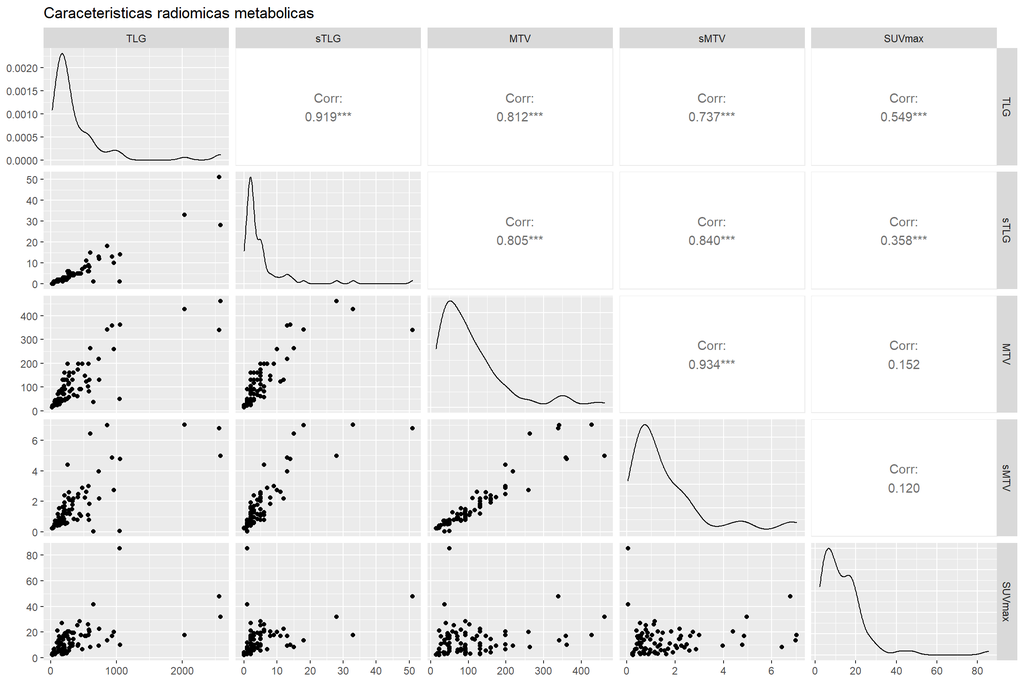

```r
metabolicas<-data[,(6:10)]
ggpairs(metabolicas, title="Caraceteristicas radiomicas metabolicas")
```

Variables texturales

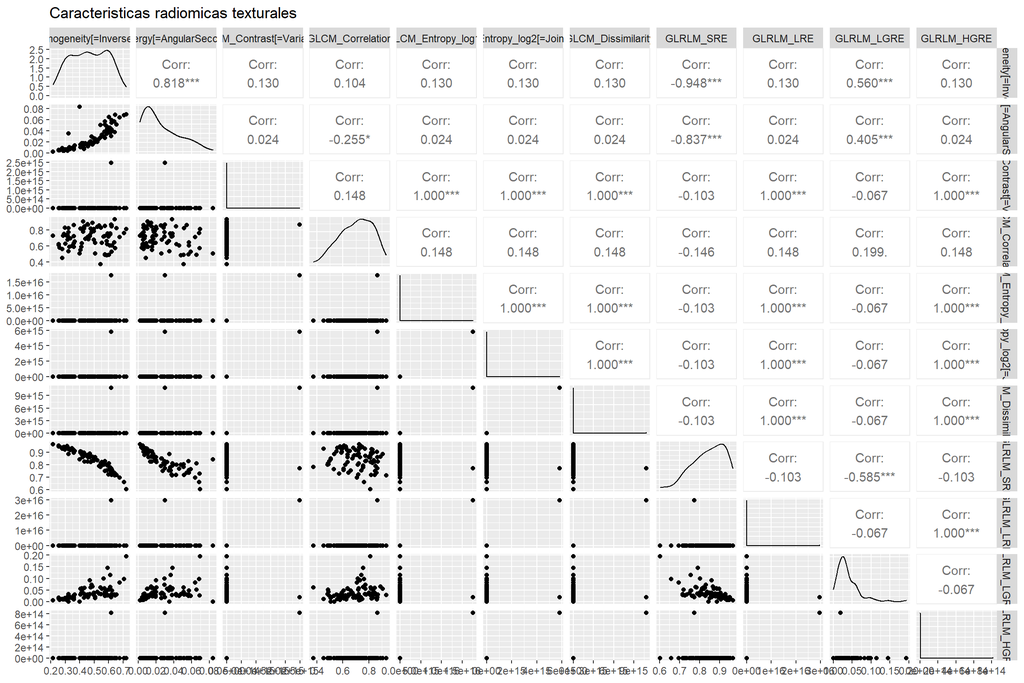

```r
texturales <-data[,11:21]
ggpairs(texturales, title = "Caracteristicas radiomicas texturales")
```

## 3.2 Evaluación gráfica de correlaciones entre ambos set de variables

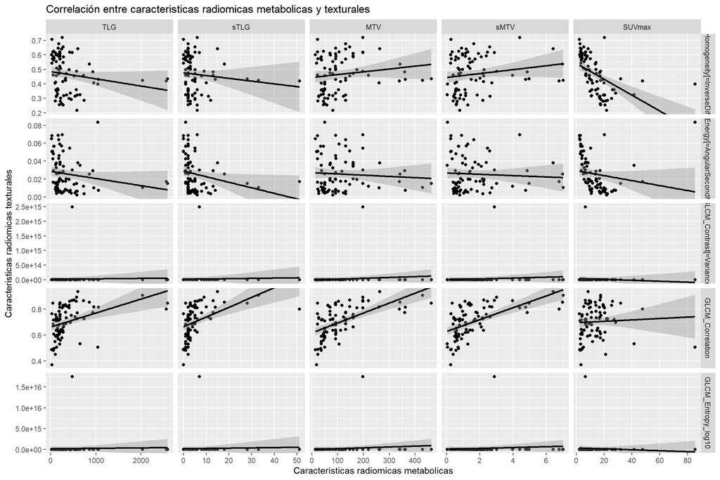

```r
ggduo(data,columnsX = 6:10,columnsY = 11:15,
      types = list(continuous = "smooth_lm"),
      title = "Correlación entre caracteristicas radiomicas metabolicas y texturales",
      xlab = "Caracteristicas radiomicas metabolicas",
      ylab = "Caracteristicas radiomicas texturales")
```

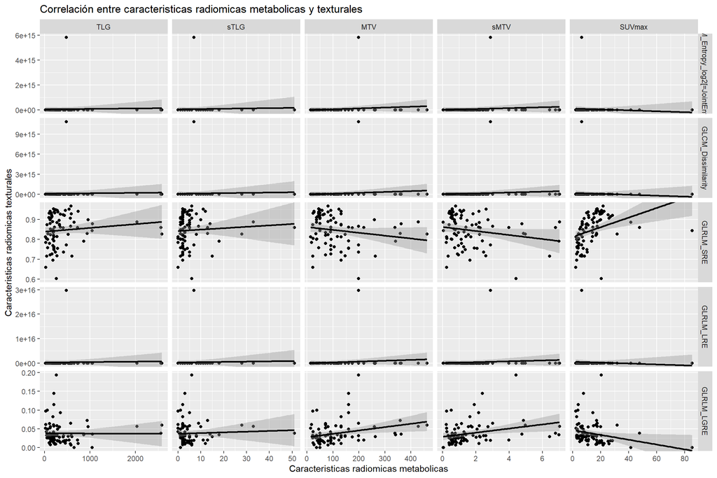

```r
ggduo(data,columnsX = 6:10,columnsY = 16:20,
      types = list(continuous = "smooth_lm"),
      title = "Correlación entre caracteristicas radiomicas metabolicas y texturales",
      xlab = "Caracteristicas radiomicas metabolicas",
      ylab = "Caracteristicas radiomicas texturales")
```

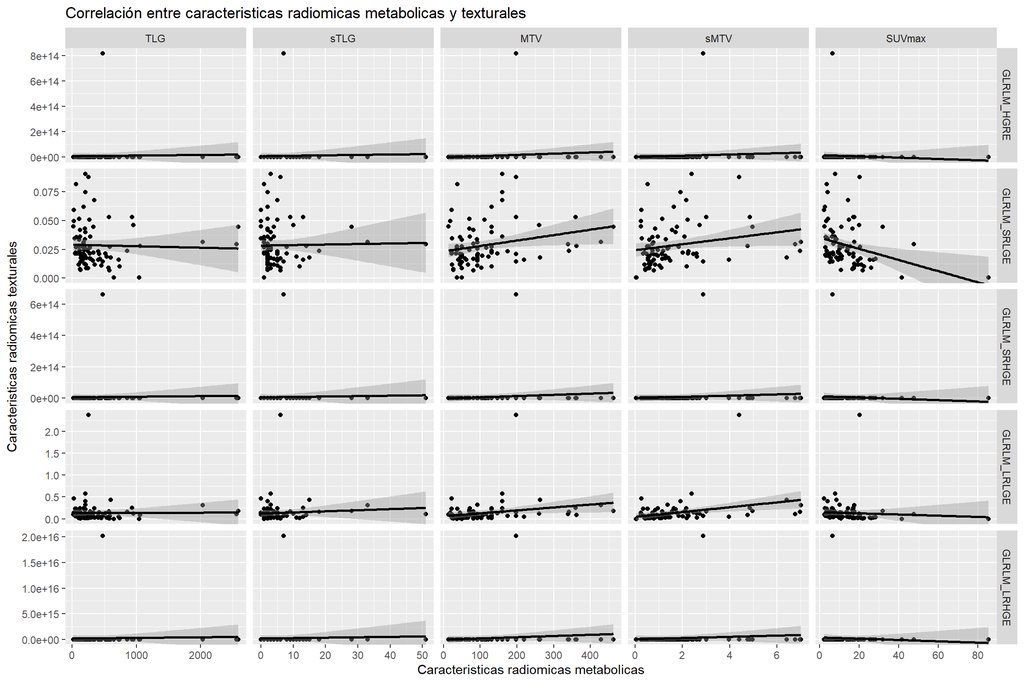

```r
ggduo(data,columnsX = 6:10,columnsY = 21:25,
      types = list(continuous = "smooth_lm"),
      title = "Correlación entre caracteristicas radiomicas metabolicas y texturales",
      xlab = "Caracteristicas radiomicas metabolicas",
      ylab = "Caracteristicas radiomicas texturales")
```

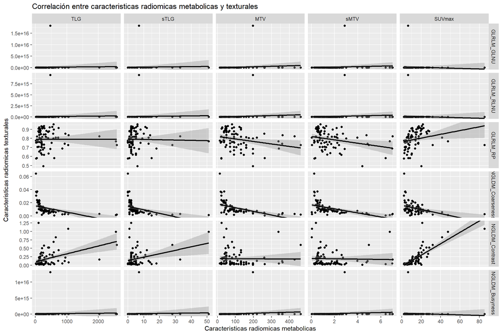

```r
ggduo(data,columnsX = 6:10,columnsY = 26:31,
      types = list(continuous = "smooth_lm"),
      title = "Correlación entre caracteristicas radiomicas metabolicas y texturales",
      xlab = "Caracteristicas radiomicas metabolicas",
      ylab = "Caracteristicas radiomicas texturales")
```

# 4 **MATRICES DE COVARIANZAS**

Como el análisis de corrrelación canónica se basa en operaciones matriciales entre ambos grupos de variables, planteamos a continuación las matrices de covarianza de X (metabólicas), Y (texturales) y las matrices de covarianzas XY e YX a modo exploratorio.

La matriz de covarianzas de X (Sxx), correspondiente a características radiómicas metabólicas,es:

```r
X<-data[,c(6, 8,10)]
cov(X)
```

```
##               TLG        MTV    SUVmax
## TLG    217250.831 36211.5423 3020.8617
## MTV     36211.542  9151.6417  171.3467
## SUVmax   3020.862   171.3467  139.2819
```

La matriz de covarianzas de Y (Syy), correspondientes a características radiómicas texturales, es:

```r
Y <-data[,c(11, 12, 14, 18, 20, 22, 28, 29, 30)]
cov(Y)
```

```
##                                      GLCM_Homogeneity[=InverseDifference]
## GLCM_Homogeneity[=InverseDifference]                         0.0164118118
## GLCM_Energy[=AngularSecondMoment]                            0.0021118873
## GLCM_Correlation                                             0.0016426409
## GLRLM_SRE                                                   -0.0096503737
## GLRLM_LGRE                                                   0.0022409095
## GLRLM_SRLGE                                                  0.0012949255
## GLRLM_RP                                                    -0.0118886514
## NGLDM_Coarseness                                             0.0001437882
## NGLDM_Contrast                                              -0.0209677004
##                                      GLCM_Energy[=AngularSecondMoment]
## GLCM_Homogeneity[=InverseDifference]                      2.111887e-03
## GLCM_Energy[=AngularSecondMoment]                         4.061477e-04
## GLCM_Correlation                                         -6.355782e-04
## GLRLM_SRE                                                -1.340391e-03
## GLRLM_LGRE                                                2.551358e-04
## GLRLM_SRLGE                                               1.343168e-04
## GLRLM_RP                                                 -1.636804e-03
## NGLDM_Coarseness                                          4.351855e-05
## NGLDM_Contrast                                           -1.488653e-03
##                                      GLCM_Correlation     GLRLM_SRE
## GLCM_Homogeneity[=InverseDifference]     0.0016426409 -9.650374e-03
## GLCM_Energy[=AngularSecondMoment]       -0.0006355782 -1.340391e-03
## GLCM_Correlation                         0.0153191813 -1.432320e-03
## GLRLM_SRE                               -0.0014323199  6.314538e-03
## GLRLM_LGRE                               0.0007698418 -1.453950e-03
## GLRLM_SRLGE                              0.0003435747 -7.674145e-04
## GLRLM_RP                                -0.0031462782  7.907992e-03
## NGLDM_Coarseness                        -0.0006821395 -6.960197e-06
## NGLDM_Contrast                          -0.0062522088  1.005920e-02
##                                         GLRLM_LGRE   GLRLM_SRLGE      GLRLM_RP
## GLCM_Homogeneity[=InverseDifference]  2.240909e-03  1.294926e-03 -0.0118886514
## GLCM_Energy[=AngularSecondMoment]     2.551358e-04  1.343168e-04 -0.0016368038
## GLCM_Correlation                      7.698418e-04  3.435747e-04 -0.0031462782
## GLRLM_SRE                            -1.453950e-03 -7.674145e-04  0.0079079924
## GLRLM_LGRE                            9.768998e-04  5.696558e-04 -0.0017200532
## GLRLM_SRLGE                           5.696558e-04  3.616737e-04 -0.0008765297
## GLRLM_RP                             -1.720053e-03 -8.765297e-04  0.0103096481
## NGLDM_Coarseness                      2.037676e-05  2.991208e-05  0.0001101216
## NGLDM_Contrast                       -2.899586e-03 -1.892829e-03  0.0111940982
##                                      NGLDM_Coarseness NGLDM_Contrast
## GLCM_Homogeneity[=InverseDifference]     1.437882e-04  -0.0209677004
## GLCM_Energy[=AngularSecondMoment]        4.351855e-05  -0.0014886528
## GLCM_Correlation                        -6.821395e-04  -0.0062522088
## GLRLM_SRE                               -6.960197e-06   0.0100592011
## GLRLM_LGRE                               2.037676e-05  -0.0028995858
## GLRLM_SRLGE                              2.991208e-05  -0.0018928292
## GLRLM_RP                                 1.101216e-04   0.0111940982
## NGLDM_Coarseness                         9.546452e-05  -0.0004609157
## NGLDM_Contrast                          -4.609157e-04   0.0629291420
```

La matriz de covarianzas de X e Y, Sxy es:

```r
cov(X,Y)
```

```
##        GLCM_Homogeneity[=InverseDifference] GLCM_Energy[=AngularSecondMoment]
## TLG                             -10.8397890                       -1.73396260
## MTV                               1.7783926                       -0.12796132
## SUVmax                           -0.7655905                       -0.03884229
##        GLCM_Correlation  GLRLM_SRE  GLRLM_LGRE GLRLM_SRLGE    GLRLM_RP
## TLG         23.35014512  4.1176972 -0.10444942 -0.27751450  0.05338671
## MTV          7.00323359 -1.3163015  0.81326159  0.43093131 -2.51440639
## SUVmax       0.07536971  0.3366493 -0.08925777 -0.06764284  0.28919975
##        NGLDM_Coarseness NGLDM_Contrast
## TLG         -2.08587821     50.3167470
## MTV         -0.51067215     -0.2808582
## SUVmax      -0.04363688      2.3585779
```

Y finalmente la matriz Syx , que es la matriz traspuesta de Sxy:

```r
cov(Y,X)
```

```
##                                               TLG        MTV      SUVmax
## GLCM_Homogeneity[=InverseDifference] -10.83978897  1.7783926 -0.76559050
## GLCM_Energy[=AngularSecondMoment]     -1.73396260 -0.1279613 -0.03884229
## GLCM_Correlation                      23.35014512  7.0032336  0.07536971
## GLRLM_SRE                              4.11769721 -1.3163015  0.33664925
## GLRLM_LGRE                            -0.10444942  0.8132616 -0.08925777
## GLRLM_SRLGE                           -0.27751450  0.4309313 -0.06764284
## GLRLM_RP                               0.05338671 -2.5144064  0.28919975
## NGLDM_Coarseness                      -2.08587821 -0.5106721 -0.04363688
## NGLDM_Contrast                        50.31674702 -0.2808582  2.35857791
```

# 5 **ANÁLISIS DE CORRELACIÓN CANÓNICA**

## 5.1 Matriz de correlación

```r
mat_cor <-matcor(X,Y)
mat_cor
```

```
## $Xcor
##              TLG       MTV    SUVmax
## TLG    1.0000000 0.8121136 0.5491649
## MTV    0.8121136 1.0000000 0.1517676
## SUVmax 0.5491649 0.1517676 1.0000000
##
## $Ycor
##                                      GLCM_Homogeneity[=InverseDifference]
## GLCM_Homogeneity[=InverseDifference]                            1.0000000
## GLCM_Energy[=AngularSecondMoment]                               0.8179947
## GLCM_Correlation                                                0.1035969
## GLRLM_SRE                                                      -0.9479711
## GLRLM_LGRE                                                      0.5596558
## GLRLM_SRLGE                                                     0.5315059
## GLRLM_RP                                                       -0.9139710
## NGLDM_Coarseness                                                0.1148746
## NGLDM_Contrast                                                 -0.6524491
##                                      GLCM_Energy[=AngularSecondMoment]
## GLCM_Homogeneity[=InverseDifference]                         0.8179947
## GLCM_Energy[=AngularSecondMoment]                            1.0000000
## GLCM_Correlation                                            -0.2548058
## GLRLM_SRE                                                   -0.8369870
## GLRLM_LGRE                                                   0.4050460
## GLRLM_SRLGE                                                  0.3504530
## GLRLM_RP                                                    -0.7998945
## NGLDM_Coarseness                                             0.2210097
## NGLDM_Contrast                                              -0.2944595
##                                      GLCM_Correlation    GLRLM_SRE  GLRLM_LGRE
## GLCM_Homogeneity[=InverseDifference]        0.1035969 -0.947971062  0.55965583
## GLCM_Energy[=AngularSecondMoment]          -0.2548058 -0.836987012  0.40504603
## GLCM_Correlation                            1.0000000 -0.145630207  0.19900256
## GLRLM_SRE                                  -0.1456302  1.000000000 -0.58540133
## GLRLM_LGRE                                  0.1990026 -0.585401333  1.00000000
## GLRLM_SRLGE                                 0.1459637 -0.507809412  0.95836079
## GLRLM_RP                                   -0.2503557  0.980107101 -0.54199458
## NGLDM_Coarseness                           -0.5640719 -0.008964576  0.06672509
## NGLDM_Contrast                             -0.2013677  0.504622717 -0.36981544
##                                      GLRLM_SRLGE   GLRLM_RP NGLDM_Coarseness
## GLCM_Homogeneity[=InverseDifference]   0.5315059 -0.9139710      0.114874599
## GLCM_Energy[=AngularSecondMoment]      0.3504530 -0.7998945      0.221009737
```

[output cut: 82 more lines]

```
## NGLDM_Coarseness                      0.16097826  0.111001726      1.000000000
## NGLDM_Contrast                       -0.39675927  0.439482197     -0.188050531
##                                      NGLDM_Contrast
## TLG                                      0.43033427
## MTV                                     -0.01170339
## SUVmax                                   0.79666726
## GLCM_Homogeneity[=InverseDifference]    -0.65244909
## GLCM_Energy[=AngularSecondMoment]       -0.29445947
## GLCM_Correlation                        -0.20136769
## GLRLM_SRE                                0.50462272
## GLRLM_LGRE                              -0.36981544
## GLRLM_SRLGE                             -0.39675927
## GLRLM_RP                                 0.43948220
## NGLDM_Coarseness                        -0.18805053
## NGLDM_Contrast                           1.00000000
```

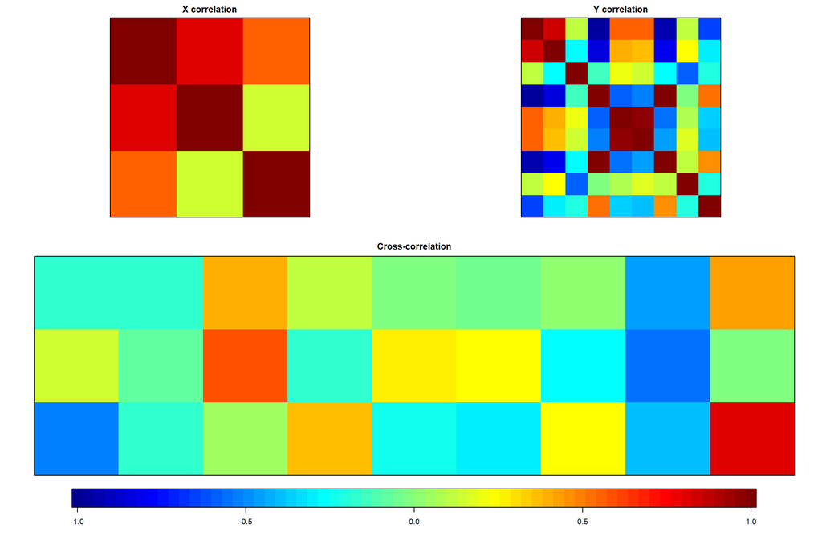

```r
img.matcor(mat_cor,type = 2)
```

## 5.2 Cálculo de correlación canónica

```r
cc1 <- cancor(X, Y)  ### funcion del R estandar
cc2 <- cc(X, Y)      ### funcion del paquete "CCA". Permite graficar y sacar coeficientes
cc3 <- cca(X, Y) ### Utilizando libreria vegan.

cc1
```

```
## $cor
## [1] 0.9241150 0.7736016 0.4753204
##
## $xcoef
##                 [,1]          [,2]          [,3]
## TLG    -1.501046e-05 -0.0003077731 -0.0005216941
## MTV    -7.210215e-06  0.0021300538  0.0013011465
## SUVmax -9.064441e-03  0.0037468108  0.0101663798
##
## $ycoef
##                                            [,1]       [,2]       [,3]
## GLCM_Homogeneity[=InverseDifference]  0.5812186  0.4012756 -2.3073659
## GLCM_Energy[=AngularSecondMoment]    -4.5358665  0.2276106  7.9110924
## GLCM_Correlation                     -0.1909948  0.2091762 -0.4563411
## GLRLM_SRE                            -2.9710252  1.1625631  0.1871412
## GLRLM_LGRE                           -0.5640464  1.5814607  3.4755369
## GLRLM_SRLGE                          -0.1625422  0.1269038 -3.8481438
## GLRLM_RP                              2.0119598 -0.4252365 -0.8038013
## NGLDM_Coarseness                      1.2910167 -7.6446096 -5.3058267
## NGLDM_Contrast                       -0.2176032 -0.0784971 -0.5965618
##                                            [,4]       [,5]        [,6]
## GLCM_Homogeneity[=InverseDifference] -1.7097134  0.4322446  -2.4154350
## GLCM_Energy[=AngularSecondMoment]    -9.3450326 -0.7206837   5.6304465
## GLCM_Correlation                     -0.6419778 -0.1706279   0.2959886
## GLRLM_SRE                            -5.2929660  1.1122888  -2.7558169
## GLRLM_LGRE                           -0.3578526  3.5649696 -14.3148542
## GLRLM_SRLGE                           0.4218719  0.8656131  23.7070541
## GLRLM_RP                              0.1073757  0.2091451  -0.1123103
## NGLDM_Coarseness                      0.4507196  1.7787225  -0.8049631
## NGLDM_Contrast                        0.0608614  0.1421303  -0.1703760
##                                             [,7]       [,8]       [,9]
## GLCM_Homogeneity[=InverseDifference]  0.94635742 -1.3577430  1.2433975
## GLCM_Energy[=AngularSecondMoment]    -5.81639895  2.1731233  3.7160272
## GLCM_Correlation                     -1.22892674  0.6073274  0.4331283
## GLRLM_SRE                             8.68889589  2.9357723 -2.6697476
## GLRLM_LGRE                            0.74453621  3.8939323  3.2176908
## GLRLM_SRLGE                           0.38276074 -5.8712018 -5.9829716
## GLRLM_RP                             -7.05024546 -3.3030028  3.0882410
## NGLDM_Coarseness                      1.75501554 13.1177561  0.8594765
## NGLDM_Contrast                       -0.05343354 -0.2166989  0.4194397
##
## $xcenter
##       TLG       MTV    SUVmax
## 375.37805 112.29268  13.71598
##
## $ycenter
## GLCM_Homogeneity[=InverseDifference]    GLCM_Energy[=AngularSecondMoment]
##                           0.46624310                           0.02561044
##                     GLCM_Correlation                            GLRLM_SRE
##                           0.70249484                           0.84642096
##                           GLRLM_LGRE                          GLRLM_SRLGE
##                           0.03820604                           0.02867332
##                             GLRLM_RP                     NGLDM_Coarseness
##                           0.79035001                           0.01186156
##                       NGLDM_Contrast
##                           0.19259417
```

```r
cc2
```

```
## $cor
## [1] 0.9241150 0.7736016 0.4753204
##
## $names
## $names$Xnames
## [1] "TLG"    "MTV"    "SUVmax"
##
## $names$Ynames
## [1] "GLCM_Homogeneity[=InverseDifference]"
## [2] "GLCM_Energy[=AngularSecondMoment]"
## [3] "GLCM_Correlation"
## [4] "GLRLM_SRE"
## [5] "GLRLM_LGRE"
## [6] "GLRLM_SRLGE"
## [7] "GLRLM_RP"
```

[output cut: 236 more lines]

```r
cc3
```

```
## Call: cca(X = X, Y = Y)
##
##                Inertia Proportion Rank
## Total         0.064795   1.000000
## Constrained   0.055171   0.851471    2
## Unconstrained 0.009624   0.148529    2
## Inertia is scaled Chi-square
##
## Eigenvalues for constrained axes:
##    CCA1    CCA2
## 0.04548 0.00969
##
## Eigenvalues for unconstrained axes:
##      CA1      CA2
## 0.007184 0.002440
```

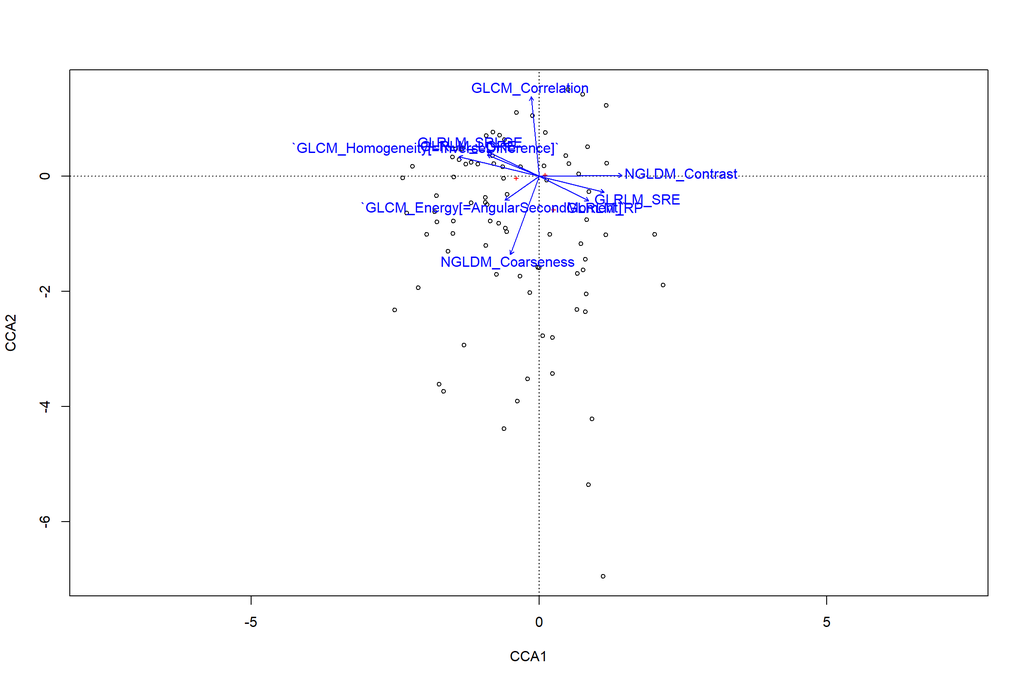

```r
plot(cc3)
```

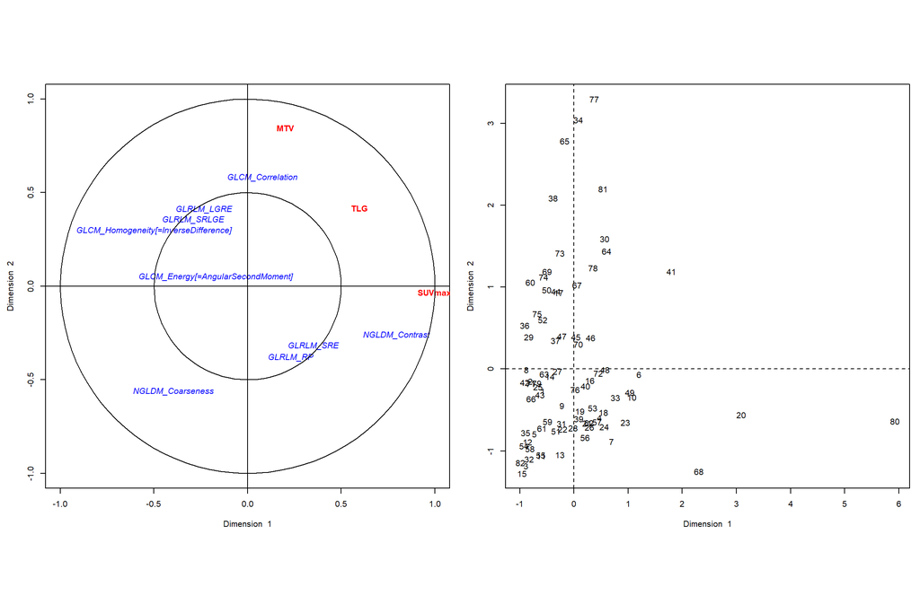

```r
plt.cc(cc(X,Y),var.label = TRUE)
```

Para el análisis, utilizamos el modelo cc2

## 5.3 Correlación canónica (R2)

```r
cc2$cor
```

```
## [1] 0.9241150 0.7736016 0.4753204
```

## 5.4 Coeficientes de correlación canónica no estandarizados (raw)

```r
cc2[3:4]
```

```
## $xcoef
##                [,1]         [,2]         [,3]
## TLG    1.350942e-04 -0.002769958 -0.004695247
## MTV    6.489194e-05  0.019170484  0.011710319
## SUVmax 8.157997e-02  0.033721297  0.091497419
##
## $ycoef
##                                            [,1]        [,2]       [,3]
## GLCM_Homogeneity[=InverseDifference]  -5.230967   3.6114805 -20.766293
## GLCM_Energy[=AngularSecondMoment]     40.822799   2.0484954  71.199831
## GLCM_Correlation                       1.718954   1.8825857  -4.107070
## GLRLM_SRE                             26.739227  10.4630677   1.684271
## GLRLM_LGRE                             5.076418  14.2331461  31.279832
## GLRLM_SRLGE                            1.462880   1.1421341 -34.633295
## GLRLM_RP                             -18.107639  -3.8271282  -7.234212
## NGLDM_Coarseness                     -11.619151 -68.8014861 -47.752440
## NGLDM_Contrast                         1.958429  -0.7064739  -5.369056
```

Los coeficientes canónicos sin procesar (raw) se interpretan de manera análoga a la interpretación de los coeficientes de regresión, es decir, para la variable “GLCM_Homogeneity”, un aumento de una unidad de la misma conduce a una disminución de 5.23 en la primera variable canónica del conjunto 2 cuando todas las demás variables se mantienen constantes.

## 5.5 Canonical Loadings

```r
cc2 <- comput(X, Y, cc2)
```

```r
cc2[3:6]
```

```
## $corr.X.xscores
##             [,1]       [,2]       [,3]
## TLG    0.5967388  0.4168286 -0.6856798
## MTV    0.2034648  0.8458230 -0.4931385
## SUVmax 0.9983103 -0.0327148  0.0480240
##
## $corr.Y.xscores
##                                             [,1]        [,2]         [,3]
## GLCM_Homogeneity[=InverseDifference] -0.49806059  0.29897838  0.013047330
## GLCM_Energy[=AngularSecondMoment]    -0.16926943  0.05161043  0.153273921
## GLCM_Correlation                      0.07883596  0.58267454 -0.167474769
## GLRLM_SRE                             0.35153872 -0.31822854 -0.049649827
## GLRLM_LGRE                           -0.23173543  0.41177052  0.059097402
## GLRLM_SRLGE                          -0.29066722  0.35487224  0.008423556
## GLRLM_RP                              0.23082310 -0.38014014 -0.031851950
## NGLDM_Coarseness                     -0.39658012 -0.56122782 -0.018328643
## NGLDM_Contrast                        0.79404658 -0.26000947 -0.094614532
##
## $corr.X.yscores
##             [,1]        [,2]        [,3]
## TLG    0.5514552  0.32245927 -0.32591760
## MTV    0.1880249  0.65433003 -0.23439879
## SUVmax 0.9225535 -0.02530822  0.02282679
##
## $corr.Y.yscores
##                                             [,1]        [,2]        [,3]
## GLCM_Homogeneity[=InverseDifference] -0.53895954  0.38647589  0.02744955
## GLCM_Energy[=AngularSecondMoment]    -0.18316923  0.06671448  0.32246443
## GLCM_Correlation                      0.08530969  0.75319714 -0.35234080
## GLRLM_SRE                             0.38040582 -0.41135970 -0.10445549
## GLRLM_LGRE                           -0.25076471  0.53227721  0.12433172
## GLRLM_SRLGE                          -0.31453577  0.45872737  0.01772185
## GLRLM_RP                              0.24977746 -0.49139004 -0.06701154
## NGLDM_Coarseness                     -0.42914586 -0.72547394 -0.03856061
## NGLDM_Contrast                        0.85925084 -0.33610253 -0.19905422
```

Las correlaciones anteriores, entre las variables observadas y las variables canónicas, se conocen como cargas canónicas. Estas variables canónicas son en realidad un tipo de variable latente.  
El número de dimensiones canónicas, también conocidas como funciones canónicas, es igual al número de variables en el conjunto más pequeño (en nuestro caso, 3 del set de metabólicas). Sin embargo, el número de dimensiones significativas puede ser incluso menor.  
Para este modelo en particular hay tres dimensiones canónicas, siendo las 3 estadísticamente significativas.

## 5.6 Tests de dimensiones canonicas

```r
rho <- cc1$cor
n <- dim(X)[1]
p <- length(X)
q <- length(Y)
```

## 5.7 Cálculo de p-valores

```r
CCP::p.asym(rho, n, p, q, tstat="Wilks")
```

```
## Wilks' Lambda, using F-approximation (Rao's F):
##                stat    approx df1      df2      p.value
## 1 to 3:  0.04538339 14.304386  27 205.0784 0.000000e+00
## 2 to 3:  0.31082067  7.043913  16 142.0000 9.612311e-12
## 3 to 3:  0.77407052  3.002112   7  72.0000 8.005193e-03
```

Cuando las variables en el modelo tienen desviaciones estándar muy diferentes, los coeficientes estandarizados permiten comparaciones más fáciles entre las variables. A continuación, calcularemos los coeficientes canónicos estandarizados.

## 5.8 Coeficientes canónicos estandarizados

```r
u1 <- cc(X, Y)
s1 <- diag(sqrt(diag(cov(X))))
s1 %*%u1$xcoef
```

```
##             [,1]       [,2]      [,3]
## [1,] 0.062967627 -1.2910822 -2.188463
## [2,] 0.006207836  1.8339293  1.120258
## [3,] 0.962788533  0.3979712  1.079832
```

```r
s2 <- diag(sqrt(diag(cov(Y))))
s2 %*% u1$ycoef
```

```
##              [,1]        [,2]       [,3]
##  [1,] -0.67013186  0.46266168 -2.6603406
##  [2,]  0.82270620  0.04128355  1.4348978
##  [3,]  0.21275605  0.23300891 -0.5083348
##  [4,]  2.12480774  0.83143791  0.1338390
##  [5,]  0.15866545  0.44486263  0.9776636
##  [6,]  0.02782064  0.02172079 -0.6586463
##  [7,] -1.83858510 -0.38859296 -0.7345361
##  [8,] -0.11352601 -0.67223143 -0.4665697
##  [9,]  0.49128531 -0.17722379 -1.3468643
```

Los coeficientes canónicos estandarizados se interpretan de manera análoga a la interpretación de los coeficientes de regresión estandarizados.  
Por ejemplo, considere la variable “GLCM_Homogeneity”, un aumento de una desviación estándar dicha variable conduce a una disminución de 0.67 desviaciones estándar en el puntaje en la primera variable canónica para el conjunto 2 cuando las otras variables en el modelo se mantienen constantes.

## 5.9 Redundancia

```r
can_redunds<- candisc::redundancy(candisc::cancor(X,Y))
can_redunds
```

```
##
## Redundancies for the X variables & total X canonical redundancy
##
##     Xcan1     Xcan2     Xcan3 total X|Y
##    0.3969    0.1776    0.0539    0.6283
##
## Redundancies for the Y variables & total Y canonical redundancy
##
##     Ycan1     Ycan2     Ycan3 total Y|X
##   0.15397   0.15060   0.00756   0.31213
```

# 6 **CONCLUSIONES**

En base a los hallazgos del análisis canónico realizado, se seleccionaron las siguientes variables para nuestro modelo de regresión logística:  
METABOLICAS.De 5 variables metabólicas seleccionadas inicialmente, nos quedaremos con 2. Ellas son: TLG y SUVmax. Estás características metabólicas son consideradas de primer orden. Son las más fáciles de extraer y, por lo tanto, las mas utilizadas en la práctica clínica (las más avaladas por bibliografia y conocimiento previo). Además, fueron las que mejor desempeño tuvieron en cross-loading.  
TEXTURALES. De 9 variables texturales seleccionadas inicialmente, nos quedaremos con 4. Ellas son: GLCM_Homogeneity, GLRLM_SRE, NGLDM_Coarseness y NGLDM_Contrast. Estas características radiómicas texturales fueron las que mejor desempeño tuvieron en cross-loading. Excluímos las restates 5 que habiamos seleccionado graficamente al inicio.  
Es decir, con el analisis de correlación canónica, pudimos reducir de 26 a solo 6 variables radiómicas explicativas para incluir en nuestro modelo logístico.